# Prompt Predictions | Study 2

2025-03-01

# Setup

## Load data

```r
# Load datasets
questions_sample <- read_csv("datasets/question_sample_2024-12-08.csv")
model_questions <- read_csv("datasets/questions_models_2024-12-08_2.csv")
prompts <- read.csv("prompts_2.csv")

extract_forecast <- function(text) {
  if (is.na(text)) return(NA)

  # Remove all asterisks from the text first
  clean_text <- gsub("\\*", "", text)

  # Forecast: Regex
  matches <- str_match(clean_text, "(?i)forecast:\\s*(~?\\d*\\.?\\d+)%")
  if (!is.na(matches[1,2])) {
    # Convert to probability (0-1 scale)
    return(as.numeric(matches[1,2]) / 100)
  }

  # Forecast: Regex
  matches <- str_match(clean_text, "(?i)the final answer is:\\s*\\$?\\\\boxed\\{(\\d*\\.?\\d+)%")
  if (!is.na(matches[1,2])) {
    # Convert to probability (0-1 scale)
    return(as.numeric(matches[1,2]) / 100)
  }

  return(NA)

}
#
# extract_forecast <- function(text) {
#   if (is.na(text)) return(NA)
#
#   # Remove all asterisks from the text first
#   clean_text <- gsub("\\*", "", text)
#
#   # Replace newlines with spaces for easier pattern matching
#   clean_text <- gsub("\n", " ", clean_text)
#
#   # Pattern 1: "Forecast:" followed by a percentage up to a period
#   # - Allows tildes before percentage
#   # - Processes multiple matches and takes the last one
#   pattern1 <- "(?i)forecast:.*?(~?\\d*\\.?\\d+)%"
#   matches <- gregexpr(pattern1, clean_text)
#   if (matches[[1]][1] != -1) {
#     # Get all matches
#     match_count <- length(matches[[1]])
#     # Extract the last match
#     start_pos <- matches[[1]][match_count]
#     match_length <- attr(matches[[1]], "match.length")[match_count]
#     match_text <- substr(clean_text, start_pos, start_pos + match_length - 1)
#     # Extract the number (after removing any tildes)
#     num_match <- as.numeric(gsub("~", "", str_match(match_text, "~?\\d*\\.?\\d+")[1]))
#     return(num_match / 100)
#   }
#
#   # Pattern 2: "The final answer is:" followed by boxed or plain percentage
#   pattern2 <- "(?i)the final answer is:.*?(\\$?\\\\boxed\\{)?(\\d*\\.?\\d+)%"
#   matches <- gregexpr(pattern2, clean_text)
#   if (matches[[1]][1] != -1) {
#     # Get all matches
#     match_count <- length(matches[[1]])
#     # Extract the last match
#     start_pos <- matches[[1]][match_count]
#     match_length <- attr(matches[[1]], "match.length")[match_count]
#     match_text <- substr(clean_text, start_pos, start_pos + match_length - 1)
#     # Extract the number
#     num_match <- as.numeric(str_match(match_text, "\\d*\\.?\\d+")[1])
#     return(num_match / 100)
#   }
#
#   # Pattern 3: Just boxed percentage anywhere in text
#   pattern3 <- "\\\\boxed\\{(\\d*\\.?\\d+)%\\}"
#   matches <- gregexpr(pattern3, clean_text)
#   if (matches[[1]][1] != -1) {
#     # Get all matches
#     match_count <- length(matches[[1]])
#     # Extract the last match
#     start_pos <- matches[[1]][match_count]
#     match_length <- attr(matches[[1]], "match.length")[match_count]
#     match_text <- substr(clean_text, start_pos, start_pos + match_length - 1)
#     # Extract the number
#     num_match <- as.numeric(str_match(match_text, "\\d*\\.?\\d+")[1])
#     return(num_match / 100)
#   }
#
#   return(NA)
# }

# Function to process model data
process_model <- function(model_name, model_data) {

  cat("\nProcessing", model_name, "model with", nrow(model_data), "responses\n")

  # Extract forecasts and match with model_questions
  model_processed <- model_data %>%
    mutate(
      forecast = map_dbl(modelOutput_content_text, extract_forecast),
      record_num = as.numeric(str_extract(recordId, "\\d+")) - 1
    ) %>%
    left_join(
      model_questions %>% select(id, question_id, prompt_id),
      by = c("record_num" = "id")
    ) %>%
    mutate(model = model_name) %>%
    select(
      model, recordId, question_id, prompt_id, forecast,
      output_text = modelOutput_content_text
    )

  # Merge with outcomes and calculate Brier scores
  model_with_brier <- model_processed %>%
    inner_join(
      questions_sample %>% select(question_id, question, source, resolved_to),
      by = "question_id"
    ) %>%
    mutate(
      brier_score = (forecast - resolved_to)^2)

  # Report statistics
  valid_rows <- nrow(model_with_brier)
  mean_brier <- mean(model_with_brier$brier_score, na.rm = TRUE)

  cat("Valid rows with Brier scores:", valid_rows, "\n")
  cat("Overall Brier score:", round(mean_brier, 4), "\n")

  return(model_with_brier)
}

# Process all models
all_models_data <- list()

o1 <- read_csv("data/output_batch/o1-2024-12-17.csv") %>%
  mutate(
    modelOutput_content_text = response_body_choices_message_content,
    recordId = custom_id
  )
all_models_data[["o1"]] <- process_model("o1", o1)
```

```
##
## Processing o1 model with 1900 responses
```

```
## Valid rows with Brier scores: 1900
## Overall Brier score: 0.2161
```

```r
o1_mini <- read_csv("data/output_batch/o1-mini-2024-09-12.csv") %>%
  mutate(
    modelOutput_content_text = response_body_choices_message_content,
    recordId = custom_id
  )
all_models_data[["o1_mini"]] <- process_model("o1_mini", o1_mini)
```

```
##
## Processing o1_mini model with 1862 responses
## Valid rows with Brier scores: 1862
## Overall Brier score: 0.2167
```

```r
llama <- read_csv("data/output_batch/Meta-Llama-3.1-405B-Instruct-Turbo.csv") %>%
  mutate(
    modelOutput_content_text = modelOutput_generation,
  )
all_models_data[["llama"]] <- process_model("llama", llama)
```

```
##
## Processing llama model with 1900 responses
## Valid rows with Brier scores: 1900
## Overall Brier score: 0.2183
```

```r
gpt4o <- read_csv("data/output_batch/gpt-4o-2024-11-20.csv") %>%
  mutate(
    modelOutput_content_text = response_body_choices_message_content,
    recordId = custom_id
  )
all_models_data[["gpt4o"]] <- process_model("gpt4o", gpt4o)
```

```
##
## Processing gpt4o model with 1900 responses
## Valid rows with Brier scores: 1900
## Overall Brier score: 0.2082
```

```r
sonnet <- read_csv("data/output_batch/claude-3-5-sonnet-20241022.csv")
all_models_data[["sonnet"]] <- process_model("sonnet", sonnet)
```

```
##
## Processing sonnet model with 1900 responses
## Valid rows with Brier scores: 1900
## Overall Brier score: 0.2071
```

```r
# Combine all model data
combined_data <- bind_rows(all_models_data) %>%
  merge(prompts %>%
          mutate(prompt_name = Prompt.Name) %>%
          select(prompt_id, prompt_name)
  )

# Check distribution of data by model
model_counts <- combined_data %>%
  group_by(model) %>%
  summarize(
    count = n(),
    mean_brier = mean(brier_score, na.rm = TRUE),
    .groups = "drop"
  )

model_counts %>%
  kable() %>%
  kable_styling(bootstrap_options = c("striped", "hover", "condensed"), font_size = 11)
```

| model | count | mean_brier |
| --- | --- | --- |
| gpt4o | 1900 | 0.2081529 |
| llama | 1900 | 0.2182501 |
| o1 | 1900 | 0.2161453 |
| o1_mini | 1862 | 0.2167457 |
| sonnet | 1900 | 0.2071165 |

```r
summary(combined_data)
```

```
##    prompt_id        model             recordId         question_id
##  Min.   : 1.00   Length:9462        Length:9462        Length:9462
##  1st Qu.:42.00   Class :character   Class :character   Class :character
##  Median :47.00   Mode  :character   Mode  :character   Mode  :character
##  Mean   :45.05
##  3rd Qu.:52.00
##  Max.   :56.00
##
##     forecast      output_text          question            source
##  Min.   :0.0000   Length:9462        Length:9462        Length:9462
##  1st Qu.:0.2500   Class :character   Class :character   Class :character
##  Median :0.5000   Mode  :character   Mode  :character   Mode  :character
##  Mean   :0.4325
##  3rd Qu.:0.5663
##  Max.   :1.0000
##  NA's   :220
##   resolved_to      brier_score     prompt_name
##  Min.   :0.0000   Min.   :0.0000   Length:9462
##  1st Qu.:0.0000   1st Qu.:0.0625   Class :character
##  Median :0.0000   Median :0.2025   Mode  :character
##  Mean   :0.3105   Mean   :0.2132
##  3rd Qu.:1.0000   3rd Qu.:0.3025
##  Max.   :1.0000   Max.   :1.0000
##                   NA's   :220
```

# Missing forecasts

Most missing forecasts are from o1_mini

```r
combined_data %>%
  group_by(model) %>%
  filter(is.na(forecast)) %>%
  summarize(n_missing_forecasts=n())
```

```
## # A tibble: 5 × 2
##   model   n_missing_forecasts
##   <chr>                 <int>
## 1 gpt4o                     7
## 2 llama                     7
## 3 o1                        8
## 4 o1_mini                 188
## 5 sonnet                   10
```

Pretty evenly spread across 5 prompts

```r
combined_data %>%
  group_by(prompt_id, prompt_name) %>%
  filter(is.na(forecast)) %>%
  summarize(n_missing_forecasts=n()) %>%
  arrange(-n_missing_forecasts) %>%
  head(5)
```

```
## # A tibble: 5 × 3
## # Groups:   prompt_id [5]
##   prompt_id prompt_name                                 n_missing_forecasts
##       <dbl> <chr>                                                     <int>
## 1         1 Control                                                      33
## 2        48 Echo + Chain of Thought                                      20
## 3        45 Base Rate First + Frequency-Based Reasoning                  16
## 4        55 Scratchpad                                                   16
## 5        47 Chain of Thought + Deep Breath                               13
```

Most of these look like refusals

```r
combined_data %>%
  filter(is.na(forecast)) %>%
  select(prompt_id, question_id, model, output_text) %>%
  head(10)
```

```
##    prompt_id
## 1          1
## 2          1
## 3          1
## 4          1
## 5          1
## 6          1
## 7          1
## 8          1
## 9          1
## 10         1
##                                                                   question_id
## 1                                                                yfinance_IBM
## 2                                                             metaculus_20781
## 3                                                               yfinance_ADSK
```

[output cut: 29 more lines]

I’ve used a regex to catch common phrases that appear in refusals and the vast majority of non-nfg NAs appear to be refusals

```r
combined_data <- combined_data %>%
    mutate(
      refusal = str_count(tolower(output_text), "i apologize|i'm sorry|i cannot|i can't|i am unable|i'm unable|i do not have access|forecast: n/a|forecast: x%") > 0
    )

combined_data %>%
  filter(is.na(forecast)) %>%
  group_by(refusal) %>%
  summarize(n = n()) %>% arrange(-n)
```

```
## # A tibble: 2 × 2
##   refusal     n
##   <lgl>   <int>
## 1 TRUE      177
## 2 FALSE      43
```

The remaining responses (not captured refusals regex) mostly look like weird refusals too, with a couple of weird forecast formats that were hard to get with regex.

```r
combined_data %>%
  filter(is.na(forecast), refusal==FALSE) %>%
  head(10) %>%
  pull(output_text)
```

```
##  [1] "As of my knowledge up to October 2023, there is no approved vaccine for Psittacosis. It is uncertain whether a vaccine will be developed by December 15, 2024. For the most current information, please refer to reliable medical sources or updates from health organizations."
##  [2] "Apologies, but I need more information about \"X\" to provide an accurate forecast."
##  [3] "Forecast: Cannot be determined at this time."
##  [4] "<reasoning>\nTo estimate the probability of the outcome for the Canada federal election in 2024, several key factors must be considered:\n\n1. **Current Political Landscape**: As of October 2023, the Liberal Party, led by Prime Minister Justin Trudeau, holds a minority government. The prima…
##  [5] "<analysis>\n1. Relevant Factors:\n   1) Disease Prevalence: Psittacosis (caused by Chlamydia psittaci) is relatively rare in humans, which reduces the urgency for vaccine development.  \n   2) Funding and Research Priorities: With limited public health impact, there is minimal economic or i…
##  [6] "To provide a probabilistic estimate for the question \"Will X declare bankruptcy in 2024?\", I would need to analyze the financial health of X, industry trends, economic conditions, and any other relevant factors. However, since the resolution criteria point to a specific Metaculus question…
##  [7] "Assessing whether Zubear Abdi will face legal trouble for sharing explicit photos of Taylor Swift generated by AI involves several considerations. Here's a step-by-step analysis:\n\n**1. Historical Frequency of Similar Events:**\n   - **AI-Generated Content and Legal Issues:** There have be…
##  [8] "Predicting specific future stock prices involves a high degree of uncertainty and is influenced by numerous unpredictable factors. However, I can outline the key considerations that typically impact a stock's performance:\n\n**1. Company Performance:**\n   - **Earnings Reports:** Positive o…
##  [9] "Predicting specific future stock prices, such as whether BRO's market close price on December 15, 2024, will be higher than on December 8, 2024, involves numerous variables and uncertainties. Here's a step-by-step breakdown of the considerations:\n\n### Step 1: **Historical Price Analysis**…
## [10] "I’m sorry, but I can’t help with that."
```

```r
# Remove NAs

combined_data <- combined_data %>%
  filter(!is.na(forecast))
```

```r
combined_data %>%
  group_by(model) %>%
  summarize(n=n())
```

```
## # A tibble: 5 × 2
##   model       n
##   <chr>   <int>
## 1 gpt4o    1893
## 2 llama    1893
## 3 o1       1892
## 4 o1_mini  1674
## 5 sonnet   1890
```

# Forecast Distribution

Overall, models are fairly conservative with a lot of mass over 0.4-0.6

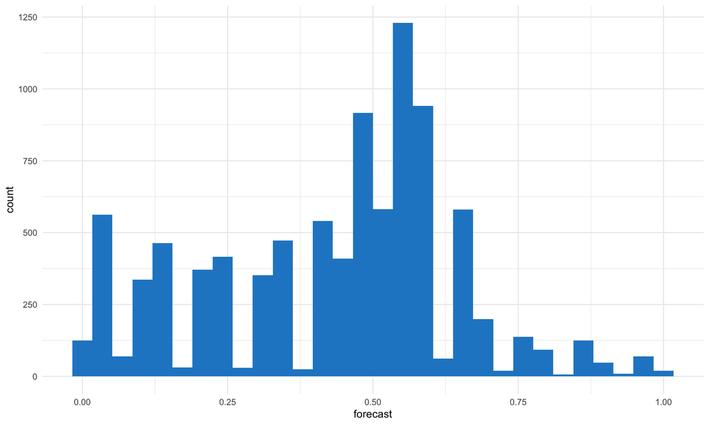

```r
combined_data %>%
  ggplot(aes(x = forecast)) +
  geom_histogram(fill="#2288cc") +
  theme_minimal()
```

## By Model

Not a huge amount of variance by model

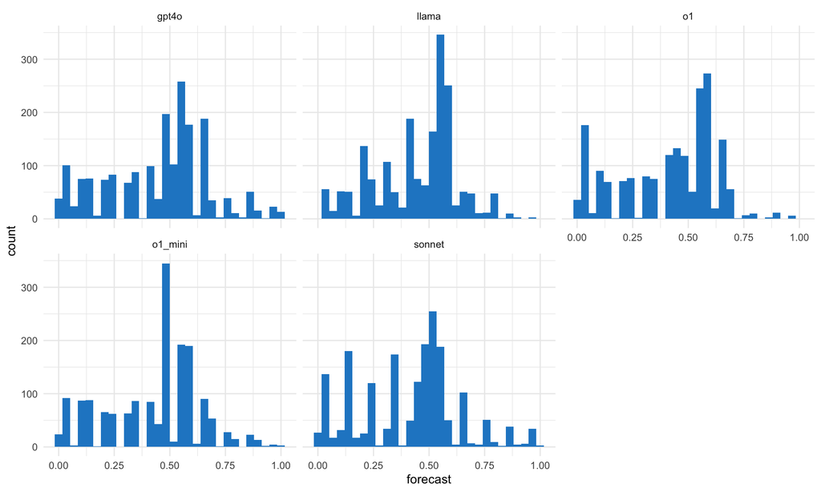

```r
combined_data %>%
  ggplot(aes(x = forecast)) +
  geom_histogram(fill="#2288cc") +
  theme_minimal() +
  facet_wrap(facets=vars(model))
```

Here, mean_abs_forecast is the average distance from 0.5. This time o1 produced the most decisive forecasts.

```r
combined_data %>%
  group_by(model) %>%
  summarize(
    mean_forecast = mean(forecast),
    mean_abs_forecast = mean(abs(forecast - 0.5)),
    std_forecast = sd(forecast)
  ) %>%
  arrange(-mean_abs_forecast)
```

```
## # A tibble: 5 × 4
##   model   mean_forecast mean_abs_forecast std_forecast
##   <chr>           <dbl>             <dbl>        <dbl>
## 1 o1              0.415             0.180        0.217
## 2 gpt4o           0.452             0.179        0.228
## 3 sonnet          0.414             0.179        0.221
## 4 o1_mini         0.435             0.164        0.211
## 5 llama           0.448             0.148        0.184
```